# Chapter 13: Non-standard Evaluation

jharner

July 6, 2015

R has powerful tools for computing not only on values, but also on the actions that lead to those values. Consider the following simple snippet of code that plots a sine curve:

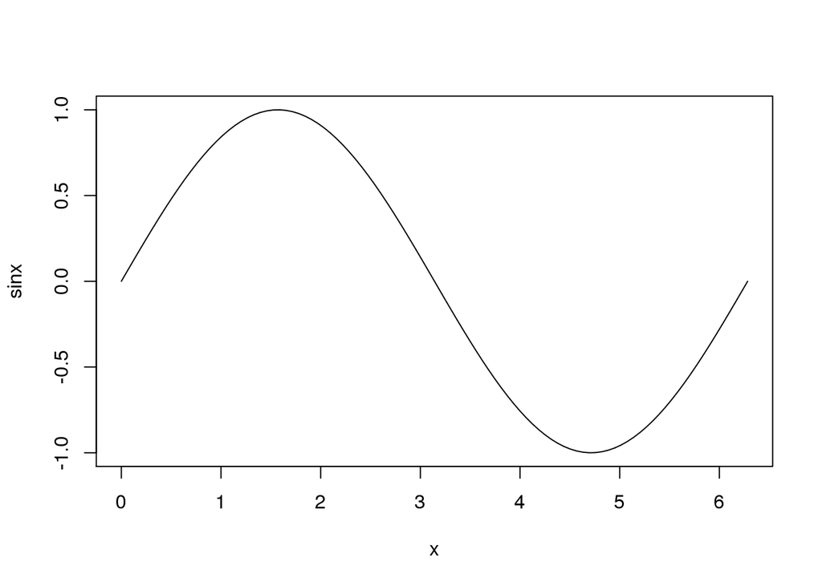

```r
x <- seq(0, 2 * pi, length = 100)
sinx <- sin(x)
plot(x, sinx, type = "l")
```

How did R know that the variable on the `x` axis is called `x` and the variable on the `y` axis is called `sinx`? In most programming languages, you can only access the values of a function’s arguments. In R, you can also access the code used to compute them. This makes it possible to evaluate code in non-standard ways: to use what is known as non-standard evaluation, or NSE for short.

## 13.1 Capturing expressions

`substitute()` makes non-standard evaluation possible. It looks at a function argument and instead of seeing the value, it sees the code used to compute the value:

```r
f <- function(x) {
  substitute(x)
}
f(1:10)
```

```
## 1:10
```

```r
x <- 10
f(x)
```

```
## x
```

```r
y <- 13
f(x + y^2)
```

```
## x + y^2
```

`substitute()` returns an expression.

`substitute()` works because function arguments are represented by a special type of object called a **promise**. A promise captures the expression needed to compute the value and the environment in which to compute it.

`substitute()` is often paired with `deparse()`. That function takes the result of `substitute()`, an expression, and turns it into a character vector.

```r
g <- function(x) deparse(substitute(x))
g(1:10)
```

```
## [1] "1:10"
```

```r
g(x)
```

```
## [1] "x"
```

```r
g(x + y^2)
```

```
## [1] "x + y^2"
```

There are a lot of functions in Base R that use these ideas. Some use them to avoid quotes:

```r
library(ggplot2)
# the same as
library("ggplot2")
```

Other functions, like `plot.default()`, use them to provide default labels. `data.frame()` labels variables with the expression used to compute them:

```r
x <- 1:4
y <- letters[1:4]
names(data.frame(x, y))
```

```
## [1] "x" "y"
```

## 13.2 Non-standard evaluation in subset

While printing out the code supplied to an argument value can be useful, we can actually do more with the unevaluated code. Take `subset()`, for example. It’s a useful interactive shortcut for subsetting data frames: instead of repeating the name of data frame many times, you can save some typing:

```r
sample_df <- data.frame(a = 1:5, b = 5:1, c = c(5, 3, 1, 4, 1))

subset(sample_df, a >= 4)
```

```
##   a b c
## 4 4 2 4
## 5 5 1 1
```

```r
# equivalent to:
# sample_df[sample_df$a >= 4, ]

subset(sample_df, b == c)
```

```
##   a b c
## 1 1 5 5
## 5 5 1 1
```

`subset()` is special because it implements different scoping rules: the expressions `a >= 4` or `b == c` are evaluated in the specified data frame rather than in the current or global environments. This is the essence of non-standard evaluation.

How does `subset()` work? We’ve already seen how to capture an argument’s expression rather than its result, so we just need to figure out how to evaluate that expression in the right context. Specifically, we want `x` to be interpreted as `sample_df$x`, not `globalenv()$x`. To do this, we need `eval()`. This function takes an expression and evaluates it in the specified environment.

Before we can explore `eval()`, we need one more useful function: `quote()`. It captures an unevaluated expression like `substitute()`, but doesn’t do any of the advanced transformations that can make `substitute()` confusing. `quote()` always returns its input as is:

```r
quote(1:10)
```

```
## 1:10
```

```r
quote(x)
```

```
## x
```

```r
quote(x + y^2)
```

```
## x + y^2
```

We need `quote()` to experiment with `eval()` because `eval()`’s first argument is an expression. So if you only provide one argument, it will evaluate the expression in the current environment. This makes `eval(quote(x))` exactly equivalent to `x`, regardless of what `x` is:

```r
eval(quote(x <- 1))
eval(quote(x))
```

```
## [1] 1
```

```r
eval(quote(y))
```

```
## [1] "a" "b" "c" "d"
```

`quote()` and `eval()` are opposites. In the example below, each `eval()` peels off one layer of `quote()`’s.

```r
quote(2 + 2)
```

```
## 2 + 2
```

```r
eval(quote(2 + 2))
```

```
## [1] 4
```

```r
quote(quote(2 + 2))
```

```
## quote(2 + 2)
```

```r
eval(quote(quote(2 + 2)))
```

```
## 2 + 2
```

```r
eval(eval(quote(quote(2 + 2))))
```

```
## [1] 4
```

`eval()`’s second argument specifies the environment in which the code is executed:

```r
x <- 10
eval(quote(x))
```

```
## [1] 10
```

```r
e <- new.env()
e$x <- 20
eval(quote(x), e)
```

```
## [1] 20
```

Because lists and data frames bind names to values in a similar way to environments, `eval()`’s second argument need not be limited to an environment: it can also be a list or a data frame.

```r
eval(quote(x), list(x = 30))
```

```
## [1] 30
```

```r
eval(quote(x), data.frame(x = 40))
```

```
## [1] 40
```

This gives us one part of `subset()`:

```r
eval(quote(a >= 4), sample_df)
```

```
## [1] FALSE FALSE FALSE  TRUE  TRUE
```

```r
eval(quote(b == c), sample_df)
```

```
## [1]  TRUE FALSE FALSE FALSE  TRUE
```

A common mistake when using `eval()` is to forget to quote the first argument. Compare the results below:

```r
a <- 10
eval(quote(a), sample_df)
```

```
## [1] 1 2 3 4 5
```

```r
eval(a, sample_df)
```

```
## [1] 10
```

```r
eval(quote(b), sample_df)
```

```
## [1] 5 4 3 2 1
```

```r
# eval(b, sample_df)
```

```
#> Error in eval(b, sample_df): object 'b' not found
```

We can use `eval()` and `substitute()` to write `subset()`. We first capture the call representing the condition, then we evaluate it in the context of the data frame and, finally, we use the result for subsetting:

```r
subset2 <- function(x, condition) {
  condition_call <- substitute(condition)
  r <- eval(condition_call, x)
  x[r, ]
}
subset2(sample_df, a >= 4)
```

```
##   a b c
## 4 4 2 4
## 5 5 1 1
```

## 13.3 Scoping issues

It certainly looks like our `subset2()` function works. But since we’re working with expressions instead of values, we need to test things more extensively. For example, the following applications of `subset2()` should all return the same value because the only difference between them is the name of a variable:

```r
y <- 4
x <- 4
condition <- 4
condition_call <- 4

subset2(sample_df, a == 4)
```

```
##   a b c
## 4 4 2 4
```

```r
subset2(sample_df, a == y)
```

```
##   a b c
## 4 4 2 4
```

```r
subset2(sample_df, a == x)
```

```
##       a  b  c
## 1     1  5  5
## 2     2  4  3
## 3     3  3  1
## 4     4  2  4
## 5     5  1  1
## NA   NA NA NA
## NA.1 NA NA NA
```

```r
subset2(sample_df, a == condition)
```

```
## [1] a b c
## <0 rows> (or 0-length row.names)
```

```r
subset2(sample_df, a == condition_call)
```

```
## [1] a b c
## <0 rows> (or 0-length row.names)
```

What went wrong? You can get a hint from the variable names I’ve chosen: they are all names of variables defined inside `subset2()`. If `eval()` can’t find the variable inside the data frame (its second argument), it looks in the environment of `subset2()`. That’s obviously not what we want, so we need some way to tell `eval()` where to look if it can’t find the variables in the data frame.

The key is the third argument to `eval()`: `enclos`. This allows us to specify a parent (or enclosing) environment for objects that don’t have one (like lists and data frames). If the binding is not found in `env`, `eval()` will next look in enclos, and then in the parents of enclos. `enclos` is ignored if `env` is a real environment. We want to look for `x` in the environment from which `subset2()` was called. In R terminology this is called the parent frame and is accessed with `parent.frame()`. This is an example of dynamic scope: the values come from the location where the function was called, not where it was defined.

With this modification our function now works:

```r
subset2 <- function(x, condition) {
  condition_call <- substitute(condition)
  r <- eval(condition_call, x, parent.frame())
  x[r, ]
}

x <- 4
subset2(sample_df, a == x)
```

```
##   a b c
## 4 4 2 4
```

Using `enclos` is just a shortcut for converting a list or data frame to an environment. We can get the same behaviour by using `list2env()`. It turns a list into an environment with an explicit parent:

```r
subset2a <- function(x, condition) {
  condition_call <- substitute(condition)
  env <- list2env(x, parent = parent.frame())
  r <- eval(condition_call, env)
  x[r, ]
}

x <- 5
subset2a(sample_df, a == x)
```

```
##   a b c
## 5 5 1 1
```

## 13.4 Calling from another function

Typically, computing on the language is most useful when functions are called directly by users and less useful when they are called by other functions. While `subset()` saves typing, it’s actually difficult to use non-interactively. For example, imagine we want to create a function that randomly reorders a subset of rows of data. A nice way to do that would be to compose a function that reorders with another that selects. Let’s try that:

```r
subset2 <- function(x, condition) {
  condition_call <- substitute(condition)
  r <- eval(condition_call, x, parent.frame())
  x[r, ]
}

scramble <- function(x) x[sample(nrow(x)), ]

subscramble <- function(x, condition) {
  scramble(subset2(x, condition))
}
```

[output not shown]

What’s gone wrong? To figure it out, let us `debug()` `subset2()` and work through the code line-by-line:

```r
debugonce(subset2)
subscramble(sample_df, a >= 4)
```

```
## debugging in: subset2(x, condition)
## debug at <text>#1: {
##     condition_call <- substitute(condition)
##     r <- eval(condition_call, x, parent.frame())
##     x[r, ]
## }
## debug at <text>#2: condition_call <- substitute(condition)
## debug at <text>#3: r <- eval(condition_call, x, parent.frame())
## debug at <text>#4: x[r, ]
```

```
##   a b c
## 4 4 2 4
## 3 3 3 1
## 2 2 4 3
## 1 1 5 5
## 5 5 1 1
```

```r
a <- 4
subscramble(sample_df, a == 4)
```

```
##   a b c
## 2 2 4 3
## 3 3 3 1
## 4 4 2 4
## 1 1 5 5
## 5 5 1 1
```

```r
a <- c(1, 1, 4, 4, 4, 4)
subscramble(sample_df, a >= 4)
```

```
##     a  b  c
## 3   3  3  1
## 5   5  1  1
## 4   4  2  4
## NA NA NA NA
```

This is an example of the general tension between functions that are designed for interactive use and functions that are safe to program with. A function that uses `substitute()` might reduce typing, but it can be difficult to call from another function.

As a developer, you should always provide an escape hatch: an alternative version of the function that uses standard evaluation. In this case, we could write a version of `subset2()` that takes an already quoted expression:

```r
subset2_q <- function(x, condition) {
  r <- eval(condition, x, parent.frame())
  x[r, ]
}
```

Here I use the suffix `_q` to indicate that it takes a quoted expression. Most users won’t need this function so the name can be a little longer.

We can then rewrite both `subset2()` and `subscramble()` to use `subset2_q()`:

```r
subset2 <- function(x, condition) {
  subset2_q(x, substitute(condition))
}

subscramble <- function(x, condition) {
  condition <- substitute(condition)
  scramble(subset2_q(x, condition))
}

subscramble(sample_df, a >= 3)
```

```
##   a b c
## 3 3 3 1
## 4 4 2 4
## 5 5 1 1
```

```r
subscramble(sample_df, a >= 3)
```

```
##   a b c
## 5 5 1 1
## 4 4 2 4
## 3 3 3 1
```

Base R functions tend to use a different sort of escape hatch. They often have an argument that turns off NSE. For example, `require()` has `character.only = TRUE`.

## 13.5 Substitute

Most functions that use non-standard evaluation provide an escape hatch. But what happens if you want to call a function that doesn’t have one? For example, imagine you want to create a lattice graphic given the names of two variables:

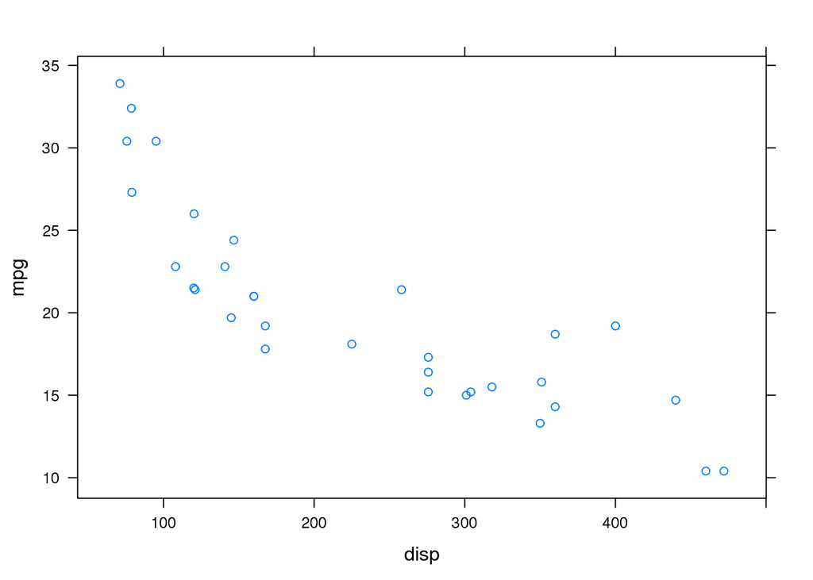

```r
library(lattice)
xyplot(mpg ~ disp, data = mtcars)
```

```r
x <- quote(mpg)
y <- quote(disp)
# xyplot(x ~ y, data = mtcars)
```

```
#> Error in tmp[subset]: object of type 'symbol' is not subsettable
```

We might turn to `substitute()` and use it for another purpose: to modify an expression. Unfortunately `substitute()` has a feature that makes modifying calls interactively a bit of a pain. When run from the global environment, it never does substitutions: in fact, in this situation it behaves just like `quote()`:

```r
a <- 1
b <- 2
substitute(a + b + z)
```

```
## a + b + z
```

However, if you run it inside a function, `substitute()` does substitute and leaves everything else as is:

```r
f <- function() {
  a <- 1
  b <- 2
  substitute(a + b + z)
}
f()
```

```
## 1 + 2 + z
```

To make it easier to experiment with `substitute()`, `pryr` provides the `subs()` function. It works exactly the same way as `substitute()` except it has a shorter name and it works in the global environment. These two features make experimentation easier:

```r
library(pryr)
a <- 1
b <- 2
subs(a + b + z)
```

```
## 1 + 2 + z
```

The second argument (of both `subs()` and `substitute()`) can override the use of the current environment, and provide an alternative via a list of name-value pairs. The following example uses this technique to show some variations on substituting a string, variable name, or function call:

```r
subs(a + b, list(a = "y"))
```

```
## "y" + b
```

```r
subs(a + b, list(a = quote(y)))
```

```
## y + b
```

```r
subs(a + b, list(a = quote(y())))
```

```
## y() + b
```

Remember that every action in R is a function call, so we can also replace `+` with another function:

```r
subs(a + b, list("+" = quote(f)))
```

```
## f(a, b)
```

```r
subs(a + b, list("+" = quote(`*`)))
```

```
## a * b
```

You can also make nonsense code:

```r
subs(y <- y + 1, list(y = 1))
```

```
## 1 <- 1 + 1
```

Formally, substitution takes place by examining all the names in the expression. If the name refers to:

1. an ordinary variable, it’s replaced by the value of the variable.
2. a promise (a function argument), it’s replaced by the expression associated with the promise.
3. `...`, it’s replaced by the contents of `....`

Otherwise it’s left as is.

```r
x <- quote(mpg)
y <- quote(disp)
subs(xyplot(x ~ y, data = mtcars))
```

```
## xyplot(mpg ~ disp, data = mtcars)
```

It’s even simpler inside a function, because we don’t need to explicitly quote the x and y variables (rule 2 above):

```r
xyplot2 <- function(x, y, data = data) {
  substitute(xyplot(x ~ y, data = data))
}
xyplot2(mpg, disp, data = mtcars)
```

```
## xyplot(mpg ~ disp, data = mtcars)
```

If we include `...` in the call to `substitute`, we can add additional arguments to the call:

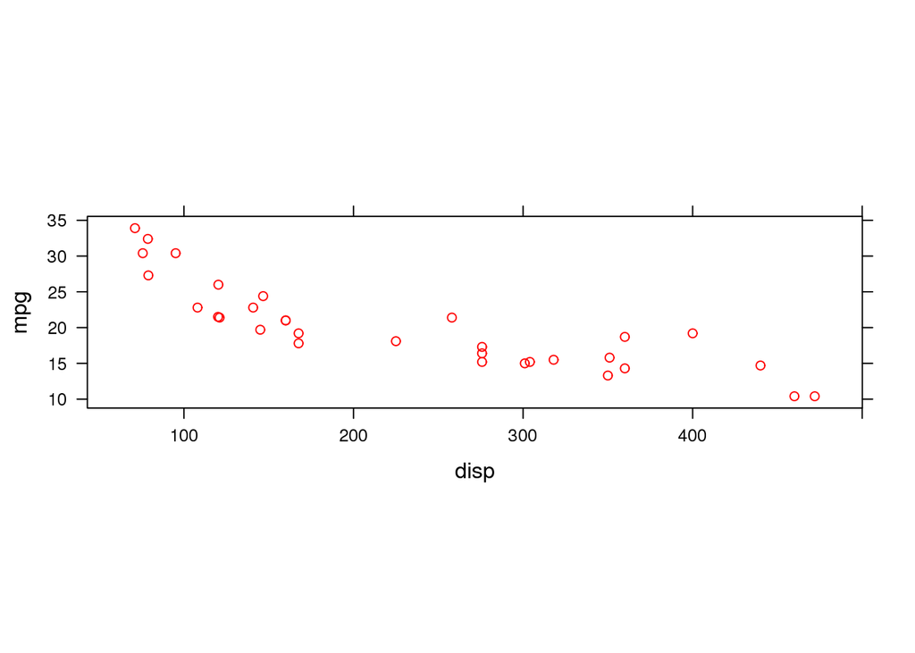

```r
xyplot3 <- function(x, y, ...) {
  substitute(xyplot(x ~ y, ...))
}
eval(xyplot3(mpg, disp, data = mtcars, col = "red", aspect = "xy"))
```

To create the plot, we’d `eval()`ed this call.

## 13.6 The downsides of non-standard evaluation

The biggest downside of NSE is that functions that use it are no longer referentially transparent. A function is referentially transparent if you can replace its arguments with their values and its behaviour doesn’t change. For example, if a function, `f()`, is referentially transparent and both `x` and `y` are `10`, then `f(x)`, `f(y)`, and `f(10)` will all return the same result. Referentially transparent code is easier to reason about because the names of objects don’t matter, and because you can always work from the innermost parentheses outwards.

There are many important functions that by their very nature are not referentially transparent. Take the assignment operator. You can’t take `a <- 1` and replace `a` by its value and get the same behaviour. This is one reason that people usually write assignments at the top-level of functions. It’s hard to reason about code like this:

```r
a <- 1
b <- 2
if ((b <- a + 1) > (a <- b - 1)) {
  b <- b + 2
}
```

Using NSE prevents a function from being referentially transparent. This makes the mental model needed to correctly predict the output much more complicated. So, it’s only worthwhile to use NSE if there is significant gain. For example, library() and require() can be called either with or without quotes, because internally they use deparse(substitute(x)) plus some other tricks. This means that these two lines do exactly the same thing:

```
library(ggplot2)
library("ggplot2")
```

Things start to get complicated if the variable is associated with a value. What package will this load?

```
ggplot2 <- "plyr"
library(ggplot2)
```

There are a number of other R functions that work in this way, like `ls()`, `rm()`, `data()`, `demo()`, `example()`, and `vignette()`.

One situation where non-standard evaluation is worthwhile is `data.frame()`. If not explicitly supplied, it uses the input to automatically name the output variables:

```r
x <- 10
y <- "a"
df <- data.frame(x, y)
names(df)
```

```
## [1] "x" "y"
```

It’s worthwhile because it eliminates a lot of redundancy in the common scenario when you’re creating a data frame from existing variables. More importantly, if needed, it’s easy to override this behaviour by supplying names for each variable.

Non-standard evaluation allows you to write functions that are extremely powerful. However, they are harder to understand and to program with. As well as always providing an escape hatch, carefully consider both the costs and benefits of NSE before using it in a new domain.